# Comprehensive Data Analysis: HRP Database

This notebook performs a comprehensive data analysis on the HRP database, covering:

1. Setup and Connection
2. Senior Demographics
3. Measurement Volume and Types
4. Medical History Linkage
5. SOS Alert Analysis
6. Duplicate Analysis
7. Random Senior Samples

## 1. Setup and Connection

Connect to the HRP database and load the first 5 rows from each table to verify the schema.

### 1.1 Connect and display DB tables

```
Tables in database: ['seniors', 'measurements', 'sqlite_sequence', 'medical_info', 'diseases', 'medicines', 'senior_diseases', 'senior_medicines', 'alerts', 'ingestion_state']
```

### 1.2 Previewing major tables

```
Previewing tables: ['seniors', 'measurements', 'alerts', 'senior_diseases', 'senior_medicines']
```

### 1.3 Overview of database tables

```
================================================================================
Table: seniors (Total rows: 13,317)
================================================================================
Columns: ['id', 'gender', 'birthdate', 'age']
Data types:
id            int64
gender       object
birthdate    object
age           int64
dtype: object

  id gender  birthdate  age
2875 Female 1955-02-26   70
3175 Female 1956-09-02   69
3176 Female 1934-08-11   91
3178   Male 1932-12-13   93
3179 Female 1941-11-04   84
================================================================================
Table: measurements (Total rows: 72,654,799)
================================================================================
Columns: ['id', 'senior_id', 'value', 'sbp', 'dbp', 'date', 'type']
Data types:
id             int64
senior_id      int64
value        float64
sbp           object
dbp           object
date          object
type          object
dtype: object

 id  senior_id  value  sbp  dbp                date        type
  1      48129   36.3 None None 2025-11-03 23:16:12 Temperature
  2      48427   36.6 None None 2025-11-03 23:16:12 Temperature
  3      45310   36.3 None None 2025-11-03 23:16:12 Temperature
  4      29421   36.6 None None 2025-11-03 23:16:12 Temperature
  5      45316   36.9 None None 2025-11-03 23:16:12 Temperature
================================================================================
Table: alerts (Total rows: 5,420)
================================================================================
```

[output cut: 29 more lines]

```
================================================================================
Table: senior_medicines (Total rows: 48,304)
================================================================================
Columns: ['senior_id', 'medicine_id']
Data types:
senior_id      int64
medicine_id    int64
dtype: object

 senior_id  medicine_id
      2875            1
      2875            2
      2875            3
      2875            4
      2875            5
```

## 2. Senior Demographics

Analyze senior population statistics, NULL values, and age outliers.

### 2.1 Load seniors table into DataFrame

### 2.2 Senior data overview

```
Total seniors: 13317
Unique senior ids: 13317
```

```
gender: 95 UNKNOWN (0.71%)
birthdate: 264 NULLs (1.98%)
age: 249 NULLs (1.87%)
```

|  | id | gender | age | birthdate |
| --- | --- | --- | --- | --- |
| 1665 | 21379 | Unknown | 69.0 | 1956-11-26 |
| 1666 | 21380 | Unknown | 78.0 | 1947-02-19 |
| 1723 | 21602 | Unknown | 77.0 | 1948-11-14 |
| 1752 | 21853 | Unknown | 69.0 | 1956-10-19 |
| 2086 | 23496 | Unknown | 79.0 | 1946-03-18 |

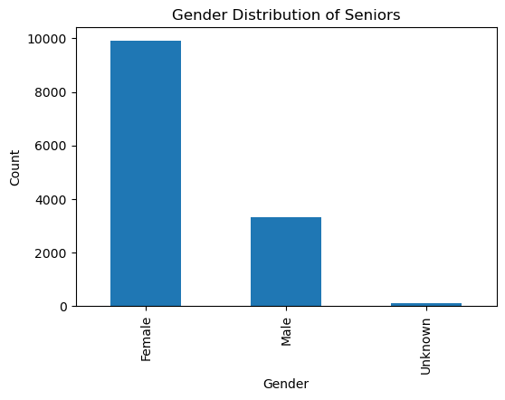

```
Min age: -75.0
Max age: 125.0
Mean age: 76.17
Median age: 77.00
```

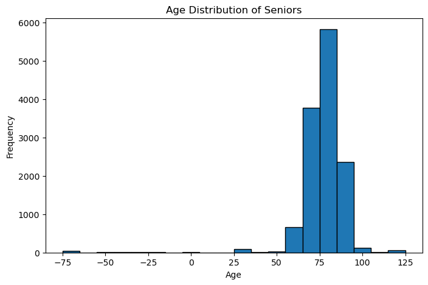

### 2.3 Seniors age outlier analysis

```
Seniors with age < 50: 210
Seniors with age > 120: 60
```

|  | id | gender | birthdate | age |
| --- | --- | --- | --- | --- |
| 802 | 12453 | Female | 2022-11-28 | 3.0 |
| 837 | 12894 | Female | 2023-01-09 | 2.0 |
| 936 | 13337 | Female | 2024-09-06 | 1.0 |
| 1204 | 18008 | Female | 2023-04-11 | 2.0 |
| 1775 | 21885 | Female | 1988-07-09 | 37.0 |
| 1791 | 21907 | Male | 2040-10-30 | -15.0 |
| 1870 | 22042 | Female | None | 125.0 |
| 2067 | 23413 | Female | None | 125.0 |
| 2107 | 23663 | Female | 2066-08-14 | -41.0 |
| 2218 | 23958 | Female | 1900-12-31 | 124.0 |

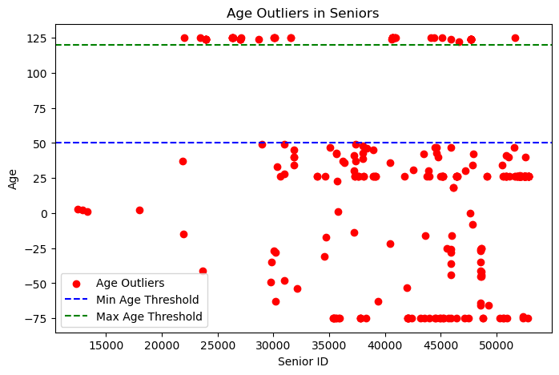

## 3. Measurement Volume and Types

Analyze measurement distribution across types and date range.

### 3.1.1 Load measurements table into DataFrame

### 3.1.2 Measurements overview

The following cells contain: measurement type distribution, date range, vital signs analysis, and daily measurements statistics.

```
Heartrate: 16,429,481 measurements (22.61%)
BloodPressure: 16,429,476 measurements (22.61%)
Temperature: 16,359,953 measurements (22.52%)
Saturation: 13,121,312 measurements (18.06%)
Steps: 10,314,577 measurements (14.20%)
```

```
Min date: 2025-11-01 00:00:02
Max date: 2025-11-30 23:59:59
Total days span: 29 days
```

```
Average measurements per senior: 5455.79
Median measurements per senior: 3524.00
Min measurements per senior: 1
Max measurements per senior: 64711
Std dev: 5767.18
```

| senior_id | mean | std | min | max |
| --- | --- | --- | --- | --- |
| 2875 | 306.625000 | 164.380209 | 8 | 515 |
| 3175 | 175.142857 | 70.033767 | 5 | 277 |
| 3176 | 75.136364 | 31.502525 | 10 | 131 |
| 3178 | 22.666667 | 17.179974 | 4 | 48 |
| 3179 | 17.714286 | 10.291004 | 4 | 32 |
| 3183 | 43.666667 | 34.355980 | 4 | 64 |
| 3184 | 61.000000 | 23.636131 | 44 | 96 |
| 3186 | 34.909091 | 23.319538 | 8 | 88 |
| 3188 | 46.266667 | 45.529373 | 4 | 165 |
| 3192 | 147.900000 | 154.338282 | 4 | 408 |

### 3.1.3 Measurement Plots

The following are plots as in the form of histograms of mean and std across seniors, top 50 seniors by mean measurements/day with error bars for std, and line graph of total measurements per day.

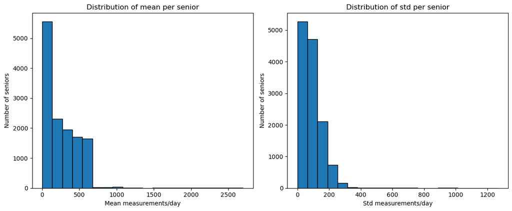

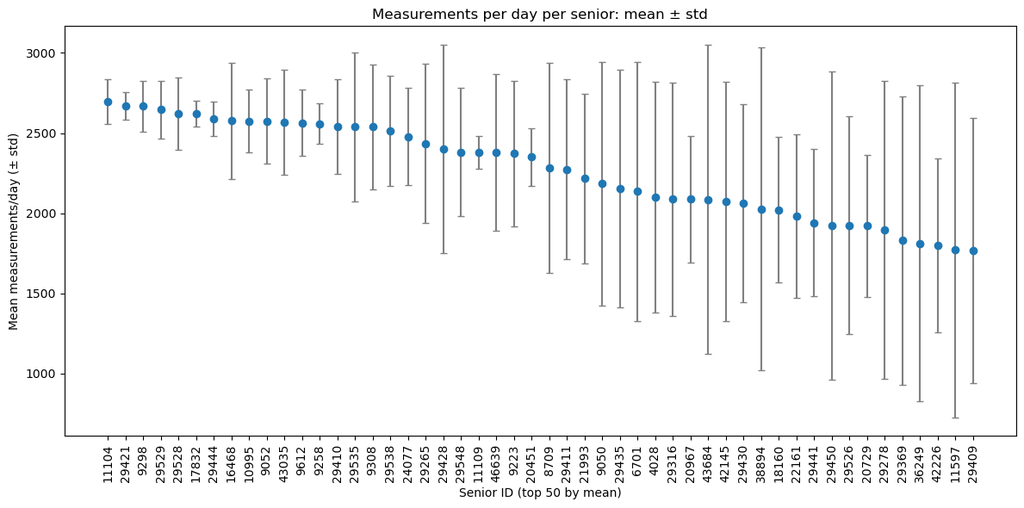

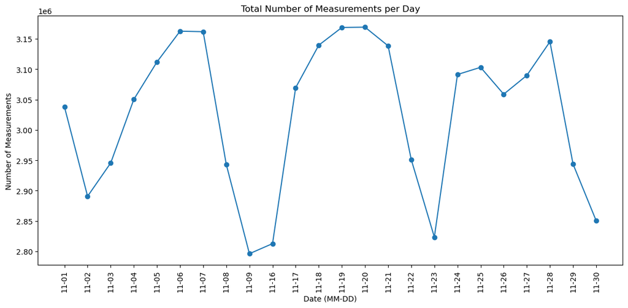

## 3.2 Measurement Type Analysis

Analyze vital signs, find outliers, and correlation between types.

### 3.2.1 Vital Sign Statistics

```
BloodPressure (SBP):
  Min: 68.00
  Max: 212.00
  Mean: 129.46
  Std: 11.90

BloodPressure (DBP):
  Min: 23.00
  Max: 157.00
  Mean: 78.69
  Std: 8.88

Heartrate:
  Min: 5.00
  Max: 210.00
  Mean: 73.39
  Std: 17.79

Saturation:
  Min: 80.00
  Max: 100.00
  Mean: 97.06
  Std: 3.32

Steps:
  Min: 1.00
  Max: 50147.00
  Mean: 3107.78
  Std: 3141.20

Temperature:
  Min: 36.20
  Max: 127.90
  Mean: 36.71
  Std: 3.03
```

### 3.2.2 Impossible values checks (outliers)

```
Temperature > 45°C or < 30°C: 18616
Saturation < 50%: 0
Heart Rate > 220 bpm or < 30 bpm: 10
SBP > 250 or < 70 mmHg: 394
DBP > 140 or < 40 mmHg: 6855
```

### 3.2.3 Blood Pressure distribution plot

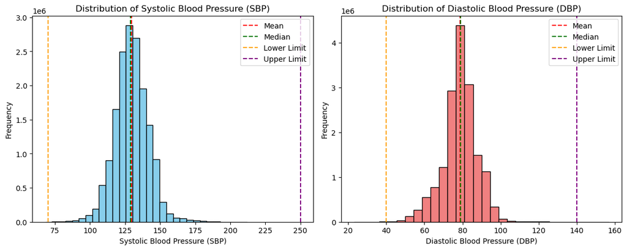

### 3.2.4 Heart Rate distribution plot

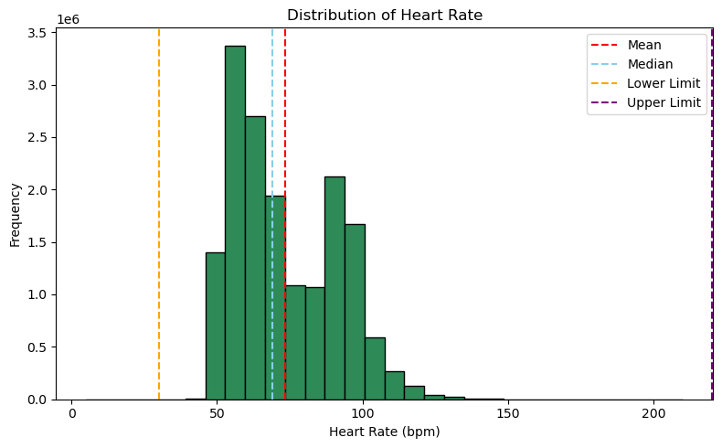

### 3.2.5 Scatter plot SBP vs DBP

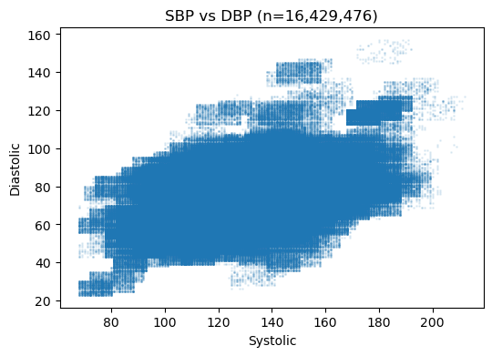

### 3.2.6 Create wide-format DataFrame

| senior_id | date | Heartrate | Saturation | Steps | Temperature | SBP | DBP |
| --- | --- | --- | --- | --- | --- | --- | --- |
| 2875 | 2025-11-01 10:12:11 | 107.0 | NaN | NaN | 36.6 | 126.0 | 87.0 |
|  | 2025-11-01 10:52:11 | 94.0 | 99.0 | NaN | 36.6 | 113.0 | 85.0 |
|  | 2025-11-01 12:12:11 | 106.0 | NaN | NaN | 36.6 | 130.0 | 80.0 |
|  | 2025-11-01 12:22:11 | 91.0 | NaN | NaN | 36.6 | 125.0 | 82.0 |
|  | 2025-11-01 12:32:11 | 111.0 | NaN | NaN | 36.5 | 130.0 | 85.0 |

### 3.2.7 Correlation matrix of vital signs

```
             Heartrate  Saturation     Steps  Temperature       SBP       DBP
Heartrate     1.000000    0.214371  0.074179    -0.002808  0.278434  0.246989
Saturation    0.214371    1.000000  0.023947    -0.001932  0.043819  0.040539
Steps         0.074179    0.023947  1.000000    -0.010330  0.011137  0.025446
Temperature  -0.002808   -0.001932 -0.010330     1.000000 -0.003040  0.001859
SBP           0.278434    0.043819  0.011137    -0.003040  1.000000  0.400547
DBP           0.246989    0.040539  0.025446     0.001859  0.400547  1.000000
```

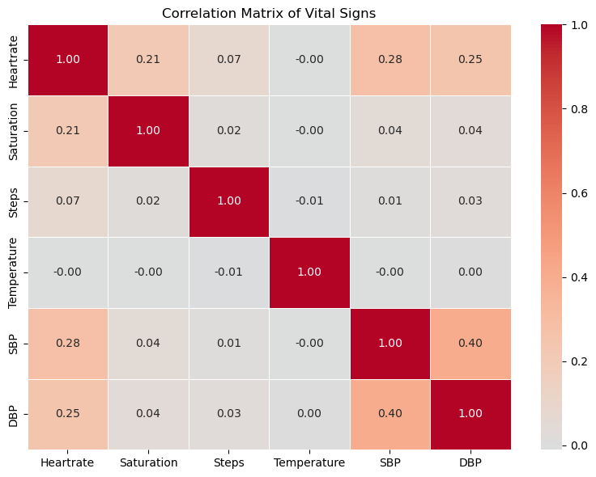

## 4. Medical History Linkage

Analyze disease and medication coverage.

### 4.1 Load disease and medicine data

### 4.2 Disease linkage

```
Seniors with at least one disease: 8220 (61.73%)
Total disease records: 49444
Avg diseases per senior (with diseases): 6.02
```

### 4.3 Medication linkage

```
Seniors with at least one medication: 8220 (61.73%)
Total medication records: 48304
Avg medications per senior (with meds): 5.88
```

## 5. Alert Analysis

Based on alert notes, analyze and categorize alerts into 4 levels:

- **Level 0:** Noise/Technical - Accidental presses or system checks. Keywords include: `przypadkowy`, `testowy`, `techniczny`, `test`
- **Level 1:** Low - Human verified that the senior is (likely) okay. Keywords include: `nawiązano kontakt`, `opiekun powiadomiony`, `brak wskazań do interwencji zrm`
- **Level 2:** Potential/Unknown - No one spoke to the senior. High uncertainty. Keywords include: `nie nawiązano kontaktu`
- **Level 3:** Acute - Highest priority. If these exist, it's a crisis. Keywords include: `interwencja zrm`, `zagrożenia życia i zdrowia`, `zdecydowano wezwać zrm`

### 5.1 Load alerts table into DataFrame

### 5.2 Number of alerts and unique seniors with alerts

```
Total alerts: 5420
Unique seniors with alerts: 3062
```

|  | alert_id | senior_id | alert_date | sos_note |
| --- | --- | --- | --- | --- |
| 0 | 1 | 3205 | 2025-11-30 17:07:51 | Alarm przypadkowy |
| 1 | 2 | 3221 | 2025-11-25 19:38:36 | Alarm przypadkowy |
| 2 | 3 | 3275 | 2025-11-14 15:01:34 | Alarm przypadkowy |
| 3 | 4 | 3279 | 2025-11-09 11:58:31 | Alarm przypadkowy |
| 4 | 5 | 3283 | 2025-11-17 18:44:32 | Alarm przypadkowy |

### 5.3 Classify alerts based on notes

### 5.4 Final severity classification

[output not shown]

### 5.5 Final severity distribution

|  | severity_label | count | percentage |
| --- | --- | --- | --- |
| 0 | 0: Noise/Tech | 4840 | 89.30 |
| 1 | 2: Potential/Unknown | 322 | 5.94 |
| 2 | 1: Low Risk | 185 | 3.41 |
| 3 | 3: Acute Crisis | 73 | 1.35 |

# 6. Duplicate Analysis

## 6.1 Duplicate `measurements` Table

### 6.1.1 Find measurements with the same senior_id, date, and type.

```
Total measurement rows: 72,654,799
Groups with duplicates (same senior_id, date, type): 810
Total duplicate measurement rows: 1,622
Percentage of measurements that are duplicates: 0.00%
```

### 6.1.2 True vs Conflicting duplicates

Analyze whether duplicates have the same value (true duplicates) or different values (conflicting data).

```
Total Duplicate Groups: 810
True Duplicates (Exact matches): 107
Conflicting Duplicates (Different values): 703
```

### 6.1.3 Duplicates by measurement type

Analyze which measurement types have the most duplicates.

| type | total_duplicate_rows | total_groups | true_duplicate_groups | conflicting_groups |
| --- | --- | --- | --- | --- |
| BloodPressure | 607 | 303 | 0 | 303 |
| Heartrate | 607 | 303 | 41 | 262 |
| Temperature | 246 | 123 | 41 | 82 |
| Saturation | 142 | 71 | 25 | 46 |
| Steps | 20 | 10 | 0 | 10 |

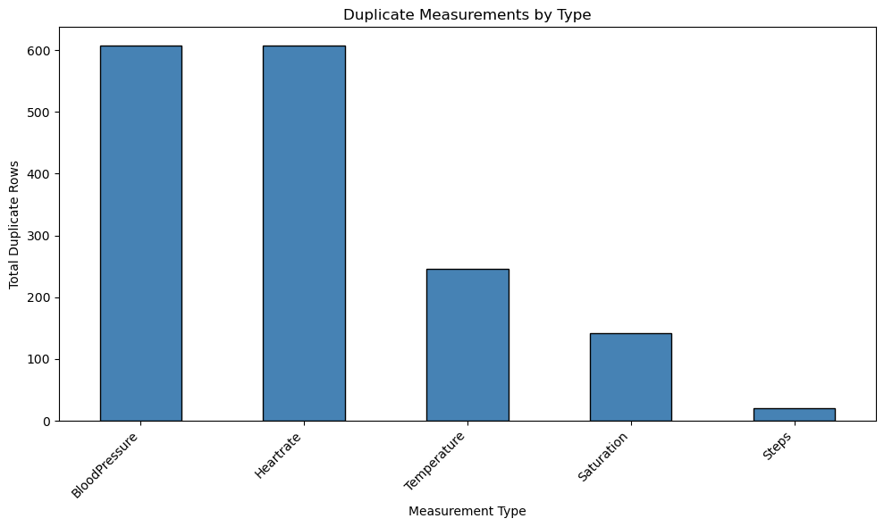

### 6.1.4 Example duplicate entries

Display sample duplicate entries for review.

```
Group: Senior 8965 | Date: 2025-11-24 13:32:11 | Type: Heartrate
 senior_id                date      type  value
      8965 2025-11-24 13:32:11 Heartrate   78.0
      8965 2025-11-24 13:32:11 Heartrate   78.0

Group: Senior 9052 | Date: 2025-11-02 18:25:38 | Type: Heartrate
 senior_id                date      type  value
      9052 2025-11-02 18:25:38 Heartrate   56.0
      9052 2025-11-02 18:25:38 Heartrate   56.0

Group: Senior 9052 | Date: 2025-11-08 15:23:03 | Type: Temperature
 senior_id                date        type  value
      9052 2025-11-08 15:23:03 Temperature   36.6
      9052 2025-11-08 15:23:03 Temperature   36.6
```

```
Group: Senior 3178 | Date: 2025-11-04 08:00:26 | Type: BloodPressure
 senior_id                date          type   sbp  dbp
      3178 2025-11-04 08:00:26 BloodPressure 164.0 81.0
      3178 2025-11-04 08:00:26 BloodPressure 165.0 82.0

Group: Senior 3178 | Date: 2025-11-04 08:00:26 | Type: Heartrate
 senior_id                date      type  value
      3178 2025-11-04 08:00:26 Heartrate   95.0
      3178 2025-11-04 08:00:26 Heartrate   78.0

Group: Senior 3348 | Date: 2025-11-06 11:24:12 | Type: BloodPressure
 senior_id                date          type   sbp  dbp
      3348 2025-11-06 11:24:12 BloodPressure 133.0 91.0
      3348 2025-11-06 11:24:12 BloodPressure 136.0 90.0
```

## 6.2 Duplicate `alerts` Table

### 6.2.1 Temporal Burst Analysis

Find cases where the same senior has multiple alerts within 10 minutes of each other. These may need to be merged into single 'Events' for ML modeling.

|  | alert_id | senior_id | alert_date | severity | time_diff | time_diff_minutes |
| --- | --- | --- | --- | --- | --- | --- |
| count | 5420.00000 | 5420.000000 | 5420 | 5420.000000 | 2358 | 2358.000000 |
| mean | 2710.50000 | 42191.084133 | 2025-11-15 16:21:08.955350272 | 0.193358 | 4 days 09:48:16.106022052 | 6348.268434 |
| min | 1.00000 | 3205.000000 | 2025-11-01 00:26:14 | 0.000000 | 0 days 00:00:00 | 0.000000 |
| 25% | 1355.75000 | 36274.000000 | 2025-11-07 13:26:35 | 0.000000 | 0 days 00:54:58 | 54.966667 |
| 50% | 2710.50000 | 46967.000000 | 2025-11-15 08:21:04 | 0.000000 | 1 days 23:04:43.500000 | 2824.725000 |
| 75% | 4065.25000 | 51275.500000 | 2025-11-23 06:11:19.500000 | 0.000000 | 6 days 20:52:51.250000 | 9892.854167 |
| max | 5420.00000 | 52896.000000 | 2025-11-30 22:51:59 | 3.000000 | 28 days 08:10:21 | 40810.350000 |
| std | 1564.76356 | 11650.467117 | NaN | 0.596378 | 5 days 15:48:28.167410550 | 8148.469457 |

```
Total alerts: 5,420
Time difference statistics (minutes):
count     2358.000000
mean      6348.268434
std       8148.469457
min          0.000000
25%         54.966667
50%       2824.725000
75%       9892.854167
max      40810.350000
Name: time_diff_minutes, dtype: float64
```

```
Alerts within 10 minutes of previous alert (same senior): 463
Percentage of all alerts: 8.54%
```

### 6.2.2 Temporal Bursts by Severity Level

|  | severity_label | burst_count | total_count | burst_percentage |
| --- | --- | --- | --- | --- |
| 0 | 0: Noise/Tech | 377 | 4840 | 7.79 |
| 1 | 2: Potential/Unknown | 50 | 322 | 15.53 |
| 2 | 1: Low Risk | 26 | 185 | 14.05 |
| 3 | 3: Acute Crisis | 10 | 73 | 13.70 |

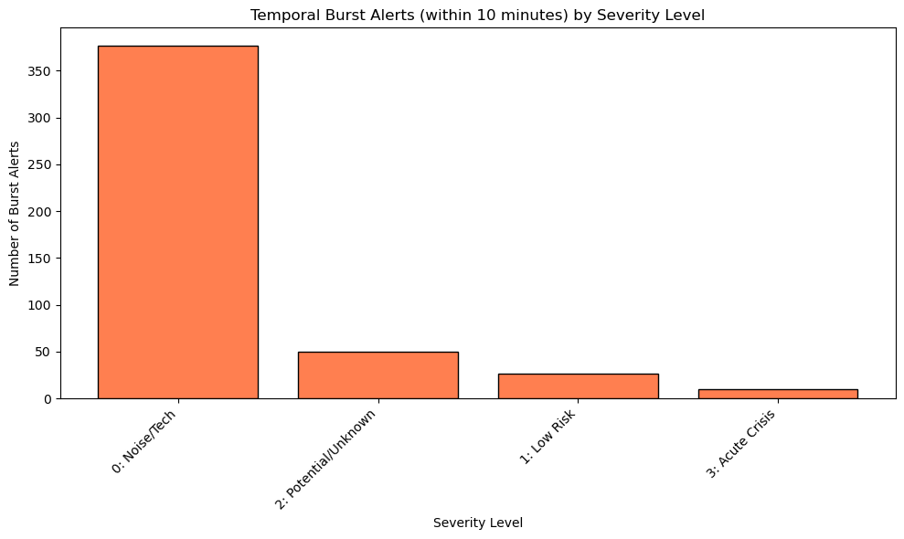

### 6.2.3 Identify Alert Burst Events

Group consecutive alerts within 10 minutes into single events.

```
Total unique alert events: 4,957
Events with multiple alerts (bursts): 306
Single-alert events: 4,651

Compression ratio: 5,420 alerts → 4,957 events (91.5%)
```

|  | alert_id | senior_id | alert_date | sos_note | severity | severity_label | time_diff | time_diff_minutes | is_burst | new_event | event_id | unique_event_id |
| --- | --- | --- | --- | --- | --- | --- | --- | --- | --- | --- | --- | --- |
| 5410 | 5412 | 52848 | 2025-11-28 18:58:14 | Alarm przypadkowy | 0 | 0: Noise/Tech | 0 days 08:01:43 | 481.716667 | False | 1 | 2 | 52848_2 |
| 5411 | 5411 | 52848 | 2025-11-28 18:58:32 | Alarm przypadkowy | 0 | 0: Noise/Tech | 0 days 00:00:18 | 0.300000 | True | 0 | 2 | 52848_2 |
| 5412 | 5410 | 52848 | 2025-11-29 19:47:27 | Alarm przypadkowy | 0 | 0: Noise/Tech | 1 days 00:48:55 | 1488.916667 | False | 1 | 3 | 52848_3 |
| 5413 | 5414 | 52862 | 2025-11-28 10:38:38 | Alarm testowy | 0 | 0: Noise/Tech | NaT | NaN | False | 1 | 1 | 52862_1 |
| 5414 | 5415 | 52876 | 2025-11-28 10:39:51 | Alarm testowy | 0 | 0: Noise/Tech | NaT | NaN | False | 1 | 1 | 52876_1 |
| 5415 | 5416 | 52882 | 2025-11-28 10:40:58 | Alarm testowy | 0 | 0: Noise/Tech | NaT | NaN | False | 1 | 1 | 52882_1 |
| 5416 | 5417 | 52883 | 2025-11-28 10:40:58 | Alarm testowy | 0 | 0: Noise/Tech | NaT | NaN | False | 1 | 1 | 52883_1 |
| 5417 | 5418 | 52891 | 2025-11-28 10:41:33 | Alarm testowy | 0 | 0: Noise/Tech | NaT | NaN | False | 1 | 1 | 52891_1 |
| 5418 | 5419 | 52894 | 2025-11-28 10:41:49 | Alarm testowy | 0 | 0: Noise/Tech | NaT | NaN | False | 1 | 1 | 52894_1 |
| 5419 | 5420 | 52896 | 2025-11-28 10:41:53 | Alarm testowy | 0 | 0: Noise/Tech | NaT | NaN | False | 1 | 1 | 52896_1 |

```
Event Size Distribution:
==================================================
alerts_in_event
1     4651
2      228
3       42
4       17
5       11
6        2
7        1
8        4
13       1
==================================================

Max alerts in single event: 13
Mean alerts per event: 1.09
```

### 6.2.4 Example Burst Events

Display examples of burst events showing multiple alerts clustered in time.

[output not shown]

# 7. Random Senior Samples

Select 3 random seniors and display their demographic information, diseases, medications, alerts, and measurement summaries.

```
============================================================
Senior ID: 47143
  Gender: Female
  Age: 85.0
  Birthdate: 1940-12-13
  Total Measurements: 2639
  Measurement Types: {'Heartrate': 595, 'BloodPressure': 595, 'Temperature': 575, 'Steps': 479, 'Saturation': 395}
  Diseases: Osteoporoza, Nadciśnienie tętnicze, Arytmia serca, Dyskopatia, Niedoczynnośc tarczycy, Niedosłuch, Miażdzyca, Niewydolność serca, Niedowidzenie, Zaćma, Następstwa udaru mózgu, Rozrusznik serca, Nerwica
  Medications: Letrox, Valsacor, Bisocard, Amlozek
  Total Alerts: 0

============================================================
Senior ID: 35017
  Gender: Male
  Age: 87.0
  Birthdate: 1938-01-01
  Total Measurements: 809
  Measurement Types: {'Steps': 741, 'Temperature': 18, 'Heartrate': 18, 'BloodPressure': 18, 'Saturation': 14}
  Diseases: Nadciśnienie tętnicze, Choroba wieńcowa, Niewydolnośc układu krążenia, Niewydolność serca, Niewydolność nerek, Choroba nowotworowa (bez wyszczególnienia), Zatorowość płucna, Stan przedcukrzycowy, Nowotwór jelita grubego, Nowotwór prostaty, Choroba zakrzepowo-zatorowa
  Medications: Nolpaza, Zaranta, Cavinton, Tolucombi, Biotropil, Pradaxa, Dalfaz
  Total Alerts: 1
  Recent Alerts:
    - 2025-11-13 14:39:26 | 0: Noise/Tech | Alarm przypadkowy...

============================================================
Senior ID: 46228
  Gender: Female
  Age: 85.0
  Birthdate: 1940-06-11
  Total Measurements: 141
  Measurement Types: {'Temperature': 37, 'Heartrate': 36, 'BloodPressure': 36, 'Saturation': 32}
  Diseases: None
  Medications: None
  Total Alerts: 0
```